# Bayes Regression Analysis

Мы ожидаем, что априорное распределение будет иметь большее значение для меньшего набора данных. Давайте построим модели с теми же двумя прайорами для датасета `english_25`, который имеет всего 25 наблюдений:

```r
english_m46 <-
  brm(
    data = english_25,
    RTlexdec ~ 1 + WrittenFrequency_c + SubjectYoung,
    family = gaussian,
    prior = c(
      prior(normal(0, 100), class = Intercept),
      prior(normal(0, 5), class = b),
      prior(exponential(1), class = sigma)
    ),
    file = "models/english_m46.brm"
  )

english_m47 <-
  brm(
    data = english_25,
    RTlexdec ~ 1 + WrittenFrequency_c + SubjectYoung,
    family = gaussian,
    prior = c(
      prior(normal(6.5, 0.5), class = Intercept),
      prior(normal(-0.05, 0.025), class = b, coef = WrittenFrequency_c),
      prior(normal(-0.5, 0.75), class = b, coef = SubjectYoung),
      prior(exponential(1), class = sigma)
    ),
    file = "models/english_m47.brm"
  )
```

Постериоры несколько у`же для модели с более сильными прайорами:

```r
## ignore the lp___ lines
posterior_summary(english_m46)
```

```
##                          Estimate  Est.Error         Q2.5         Q97.5
## b_Intercept            6.58653514 0.02070050   6.54481119   6.627854463
## b_WrittenFrequency_c  -0.01917834 0.01438379  -0.04795688   0.008786603
## b_SubjectYoung        -0.26359639 0.04336523  -0.34938569  -0.175251669
## sigma                  0.10323215 0.01660539   0.07629041   0.140845266
## Intercept              6.57071936 0.02055496   6.52897104   6.611268350
## lprior               -10.68769125 0.01662175 -10.72545399 -10.660670535
## lp__                   8.97756992 1.55712057   5.11383904  10.889990964
```

```r
##                          Estimate  Est.Error         Q2.5        Q97.5
## b_Intercept            6.53836217 0.01845433   6.50196687   6.57404141
## b_WrittenFrequency_c  -0.04901830 0.01128223  -0.07106459  -0.02665495
## b_SubjectYoung        -0.23340083 0.03792993  -0.30868792  -0.15901430
## sigma                  0.08945753 0.01426544   0.06557531   0.12077997
## Intercept              6.55236622 0.01831929   6.51681381   6.58805880
## lprior               -10.67363471 0.01427671 -10.70526677 -10.64972072
## lp__                  12.52561066 1.51741568   8.75156583  14.46203528
posterior_summary(english_m47)
```

```
##                         Estimate  Est.Error        Q2.5        Q97.5
## b_Intercept           6.58697027 0.02160118  6.54471444  6.629529059
## b_WrittenFrequency_c -0.02638784 0.01249230 -0.05147794 -0.001637224
## b_SubjectYoung       -0.26070017 0.04402897 -0.34594225 -0.175125726
## sigma                 0.10417316 0.01679415  0.07783242  0.142986166
## Intercept             6.57132826 0.02143949  6.52888040  6.614049851
## lprior                1.17415866 0.49391076 -0.11997558  1.734674424
## lp__                 20.77764555 1.56772040 16.87747664 22.710995082
```

```r
##                         Estimate  Est.Error        Q2.5       Q97.5
## b_Intercept           6.53848390 0.01768429  6.50431144  6.57348920
## b_WrittenFrequency_c -0.04904812 0.01043104 -0.06942174 -0.02800759
## b_SubjectYoung       -0.23346989 0.03568194 -0.30595350 -0.16397522
## sigma                 0.08844702 0.01394459  0.06615899  0.12049948
## Intercept             6.55249210 0.01756967  6.51777487  6.58716219
## lprior                1.66629299 0.13806210  1.30950223  1.77944045
## lp__                 25.05601074 1.46951405 21.26935084 26.89074865
```

Более информативное априорное распределение будет иметь большее значение в следующих случаях:

- При меньшем объеме данных относительно сложности модели.
- В других ситуациях, когда задача вывода «более сложная», например, когда предикторы коррелированы.

```r
english_collin_m2 <-
  brm(
    data = english_25,
    RTlexdec ~ 1 + WrittenFrequency_c + Familiarity_c + SubjectYoung,
    family = gaussian,
    prior = c(
      prior(normal(6.5, 0.5), class = Intercept),
      prior(normal(-0.05, 0.025), class = b, coef = WrittenFrequency_c),
      prior(normal(-0.05, 0.025), class = b, coef = Familiarity_c),
      prior(normal(-0.5, 0.25), class = b, coef = SubjectYoung),
      prior(exponential(1), class = sigma)
    ),
    file = "models/english_collin_m2.brm"
  )
```

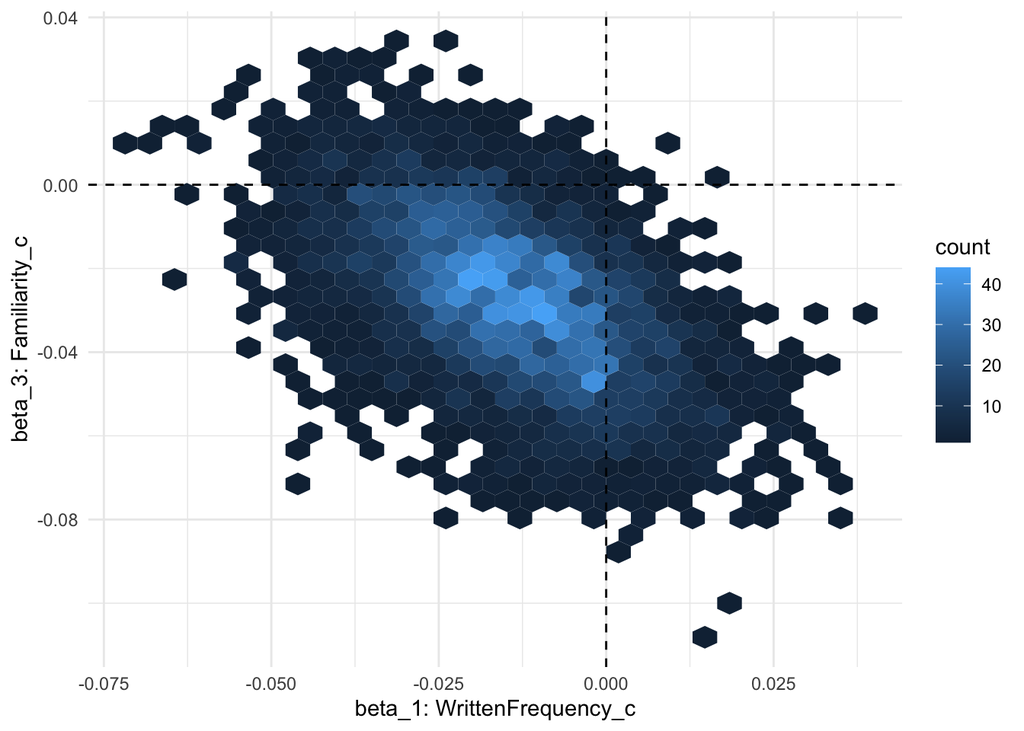

```r
# heatmap of posterior for two coefficients, with lines at beta_1, beta_3 = 0
english_collin_m2 %>%
  spread_draws(b_WrittenFrequency_c, b_Familiarity_c) %>%
  ggplot(aes(x = b_WrittenFrequency_c, y = b_Familiarity_c)) +
  geom_hex() +
  xlab("beta_1: WrittenFrequency_c") +
  ylab("beta_3: Familiarity_c") +
  geom_vline(aes(xintercept = 0), lty = 2) +
  geom_hline(aes(yintercept = 0), lty = 2)
```

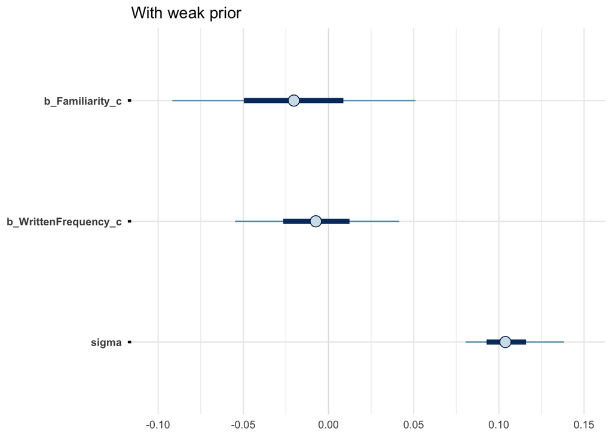

```r
mcmc_plot(english_collin_m1, variable = c("b_Familiarity_c", "b_WrittenFrequency_c", "sigma")) + ggtitle("With weak prior")
```

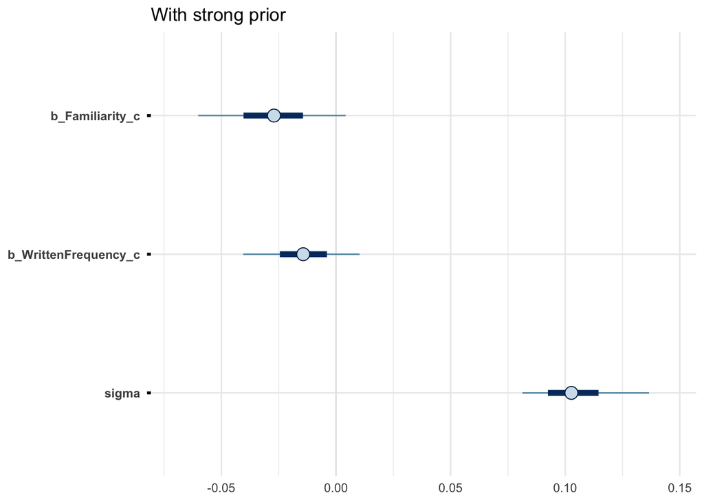

```r
mcmc_plot(english_collin_m2, variable = c("b_Familiarity_c", "b_WrittenFrequency_c", "sigma")) + ggtitle("With strong prior")
```

**Упражнение**

Проведите предварительную проверку прогностической способности модели `english_m45_prior` на предмет частичного эффекта параметра `AgeSubject`. Интерпретируйте полученный график.

## Полезное

- Тетрадка основана на главах курсов Sonderegger et al. 2025 и Мороз 2026.
  - https://people.linguistics.mcgill.ca/~morgan/adv-quant-methods/bayesian-basics-2.html
  - https://people.linguistics.mcgill.ca/~morgan/adv-quant-methods/bayesian-regression-models-1.html
  - https://agricolamz.github.io/2026_HSE_b_da4l/08-introduction_to_bayesian_regression_with_brms.html
- Вычисление байесовского фактора (BF) для моделей https://rpubs.com/lindeloev/bayes_factors
- Визуализация байесовского фактора https://statsedge.org/shiny/LearnBF/